# Prezentacija testiranih strategija trgovanja

### UVOD

Od posljednjeg sastanka naglasak sam stavio na procjenu tržišnog rizika, to jest rizika naglog pada vrijednosti dionice (SPY-a). Proučavao sam relevantnu literaturu (znanstvene radove i knjige) i pokušao na temelju njih i vlastite intuicije razviti profitabilne strategije. U nastavku dajem prikaz većine strategija koje sam probao.

### ZAŠTITA PUT OPCIJOM

Ova strategija je kopija stretegije dostupne na ovom [videu](https://www.youtube.com/watch?v=Lq-Ri7YU5fU). Općenito, kupnjom put opcije štitimo se od rizika pada cijena. Konstantna zaštita put opcijom je relativno skupa. Ideja je stoga zaštiti se put opcijom kada je tržišni rizik visok. Točnije kupujemo put opciju kada VIX “Volatility index” prijeđe određenu razinu (npr. 25). Volatility index se računa kao

$$VI = (VIX_t - min(VIXhistory_{low})) / (max(VIXhistory_{high} - min(VIXhistory_{low}))))$$

Intuitivno, kupujemo put opciju kada je vrijednost VIX-a visoka. Što je visoko određeno je indeksom volatilnosti.

Strategija je direktno razvijena u QC okruženju. Naziv projekta je “Put Option Protection”.

Strategija ostvaruje dobre rezultate za razdoblje COVID krize, ali ne i za razdoblje Velike recesije. U najdužem periodu promatranja (2006-2020) strategija donosi prinos od **160%** dok strategija ‘Kupi drži’ donosi prinos od **219%**.

Bolje rezultate moguće je postići uglađivanjem parametara:

```python
self.DaysBeforeExp = 2 # number of days before expiry to exit
self.DTE = 25 # target days till expiration
self.OTM = 0.01 # target percentage OTM of put
self.lookbackIV = 300 # lookback length of IV indicator
self.IVlvl = 0.5 # enter position at this lvl of IV indicator
self.percentage = 0.9 # percentage of portfolio for underlying asset
self.options_alloc = 90 # 1 option for X num of shares (balanced would be 100)
```

### VIX STRATEGIJE

Strategija je slična prethodnoj u smislu da koristi VIX kao input varijablu za mjerenje rizika. Međutim umjesto VI indeksa, izlazak iz pozicije i ulazak u poziciju se određuje iz stope rasta VIX indeksa ili iz percentila za prethodnih X razdoblja. Strategija je razvijena unutar QC okruženja na dnevnim podacima.

Navodim primjer jedne strategije.Na početku kupujemo SPY. Prodajemo ako su zadovoljena dva uvjeta: vrijednost VIX-a je veća od 20 i stopa rasta VIX-a u prethodnom razdoblju iznosi barem 5%. Ponovno kupujemo SPY kada stopa rata VIX-a dosegne -3%.

Bolje rezultate moguće je postići uglađivanjem parametara:

```python
vix_level = 20 # vrijendot VIX-a nakon kojeg slijedi potencijalna prodaja
growth_rate_sell = 0.05  # stopa rasta koju VIX mora doseći da bi se izašlo iz pozicije
growth_rate_buy = -0.03  # stopa rasta koju VIX mora doseći da bi se ušlo u poziciju
```

Na prethodnoj prezentaciji sam pokazivao slične strategije s VIX-om, koje prodaju poziciju ako VIX naraste iznad određenog percentila vrijednosti (npr. iznad 90% percentila). Također sam pokazao i varijantu gdje se na VIX primjenjuje regresijska analiza i onda se koriste regresijski koeficijenti za analizu.

Nijedna od VIX strategija nije pokazala zadovoljavajuće rezultate.

# VAR (ES) STRATEGIJE

Dvije su osnovne mjere (tržišnog) rizika u području kvantitativnog *risk managementa*:

1. VaR (Value at risk) - vjerojatnost (alpha) da gubitak bude veći od x iznosi 5%. Percentil distribucije.
2. ES (Expected Shortfall) - očekivani gubitak za vrijednosti X > VaR.

Ove mjere ću detaljnije objasniti za vrijeme prezentacije

Isprobao sam mnoštvo strategije na temelju ove dvije mjere. Prikazat ću samo neke varijacije koje su bile profitabilne barem u nekim varijacijama.

### PRIPREMA

Učitavam potrebne pakete:

```r
library(data.table)
library(purrr)
library(ggplot2)
library(quantmod)
library(future.apply)
library(PerformanceAnalytics)
library(roll)
library(TTR)
library(GAS)
library(parallel)         # for the GASS package
library(BatchGetSymbols)  # import data

source('C:/Users/Mislav/Documents/GitHub/alphar/R/parallel_functions.R')
source('C:/Users/Mislav/Documents/GitHub/alphar/R/outliers.R')
source('C:/Users/Mislav/Documents/GitHub/alphar/R/import_data.R')
source('C:/Users/Mislav/Documents/GitHub/alphar/R/features.R')

# performance
plan(multiprocess(workers = availableCores() - 8))
```

Učitavam podatke potrebne za analizu:

```r
# PARAMETRI
contract = 'SPY'
freq = 5  # 1 is one minute, 60 is hour, 480 is day etc
upsample = FALSE
add_fundamentals = FALSE
add_vix = FALSE

# PODACI
if (freq < 60) {
  paste0(contract, freq)
  # HFD
  market_data <- import_mysql(
    contract = paste0(contract, freq),
    save_path = 'D:/market_data/usa/ohlcv',
    trading_days = TRUE,
    upsample = upsample,
    RMySQL::MySQL(),
    dbname = 'odvjet12_market_data_usa',
    username = 'odvjet12_mislav',
    password = 'Theanswer0207',
    host = '91.234.46.219'
  )
  vix <- import_mysql(
    contract = paste0(contract, freq),
    save_path = 'D:/market_data/usa/ohlcv',
    trading_days = TRUE,
    upsample = upsample,
    RMySQL::MySQL(),
    dbname = 'odvjet12_market_data_usa',
    username = 'odvjet12_mislav',
    password = 'Theanswer0207',
    host = '91.234.46.219'
  )
} else if (freq == 480) {
  market_data <- BatchGetSymbols(tickers = contract, first.date = '2000-01-01')[[2]]
  market_data <- xts::xts(market_data[, c(1:6, 9, 10)], order.by = market_data$ref.date)
  market_data$returns <- market_data$ret.adjusted.prices
} else {
  # LFD
  market_data <- import_ib(
    contract = contract,
    frequencies = ifelse(freq == 60, '1 hour', '1 day'),
    duration = '30 Y',
    type = 'equity',
    trading_days = FALSE,
    what_to_show = 'TRADES'
  )
  colnames(market_data) <- c('open', 'high', 'low', 'close', 'volume', 'WAP', 'hasGaps', 'count')
  vix <- import_ib(
    contract = 'VIX',
    frequencies = ifelse(freq == 60, '1 hour', '1 day'),
    duration = '30 Y',
    type = 'index',
    trading_days = FALSE
  )
  colnames(vix) <- c('open', 'high', 'low', 'close', 'volume', 'WAP', 'hasGaps', 'count')
}
```

```
## [1] "Read from local file. The data is 60.58 days old."
## [1] "Read from local file. The data is 60.58 days old."
```

```r
# FUNDAMENTALS
if (add_fundamentals) {
  fundamentals <- simfinapi::sfa_get_statement(Ticker = contract,
                                               statement = 'all',
                                               period = 'quarters',
                                               ttm = TRUE,
                                               shares = TRUE,
                                               api_key = '8qk9Xc9scFc0Rbpfrx6PLdaiomvi7Dxc')
  if (!is.null(fundamentals)) {
    fundamentals <- janitor::clean_names(fundamentals)
    fundamentals <- fundamentals[, .(publish_date, shares, sales_per_share)]
    fundamentals <- xts::xts(fundamentals[, 2:ncol(fundamentals)], order.by = as.POSIXct(fundamentals$publish_date))
    market_data <- merge(market_data, fundamentals, all = TRUE)
    market_data$sales_per_share <- zoo::na.locf(market_data$sales_per_share)
    market_data <- market_data[!is.na(market_data$close), ]
    market_data$ps <- market_data$close / market_data$sales_per_share
  }
}
```

Čišćenje podataka:

```r
# Remove outliers
market_data <- remove_outlier_median(market_data, median_scaler = 25)

# merge market data and VIX
if (add_vix) {
  market_data <- merge(market_data, vix[, 'close'], join = 'left')
  colnames(market_data)[ncol(market_data)] <- 'vix'
  market_data <- na.omit(market_data)
}

# Add features
market_data <- add_features(market_data)

# Remove NA values
market_data <- na.omit(market_data)
head(market_data)
```

```
##                       open   high    low  close volume average barCount hi_lo
## 2004-02-02 20:40:00 114.35 114.44 114.32 114.40   4635 114.386      344  0.12
## 2004-02-02 20:45:00 114.40 114.55 114.36 114.55   4849 114.481      399  0.19
## 2004-02-02 20:50:00 114.54 114.55 114.47 114.49   1014 114.514      172  0.08
## 2004-02-02 20:55:00 114.48 114.57 114.41 114.49   2576 114.515      330  0.16
## 2004-02-02 21:00:00 114.50 114.54 114.45 114.51   1404 114.492      234  0.09
## 2004-02-02 21:05:00 114.49 114.53 114.23 114.34   4692 114.308      509  0.30
##                     cl_op cl_ath       returns returns_squared        std_5
## 2004-02-02 20:40:00  0.05 115.89  0.0004372540    1.911911e-07 0.0007057493
## 2004-02-02 20:45:00  0.15 115.89  0.0013111888    1.719216e-06 0.0009590354
## 2004-02-02 20:50:00 -0.05 115.89 -0.0005237887    2.743546e-07 0.0009787702
## 2004-02-02 20:55:00  0.01 115.89  0.0000000000    0.000000e+00 0.0007502876
## 2004-02-02 21:00:00  0.01 115.89  0.0001746877    3.051581e-08 0.0006752122
## 2004-02-02 21:05:00 -0.15 115.89 -0.0014845865    2.203997e-06 0.0010214552
##                           std_10       std_20       std_40      std_80
## 2004-02-02 20:40:00 0.0005480451 0.0005797257 0.0008682741 0.001137574
## 2004-02-02 20:45:00 0.0006931226 0.0006503268 0.0008730270 0.001090472
## 2004-02-02 20:50:00 0.0006742527 0.0006592852 0.0008711296 0.001089762
## 2004-02-02 20:55:00 0.0006732504 0.0006399925 0.0008713987 0.001075083
## 2004-02-02 21:00:00 0.0006744421 0.0006383459 0.0008687532 0.001072093
## 2004-02-02 21:05:00 0.0008277539 0.0006995878 0.0009044824 0.001086032
##                         std_150      std_300        ctc  parkinson      rogers
## 2004-02-02 20:40:00 0.001091434 0.0008908760 0.01252172 0.01095351 0.010504976
## 2004-02-02 20:45:00 0.001096249 0.0008940798 0.01764652 0.01162043 0.009640786
## 2004-02-02 20:50:00 0.001095963 0.0008925368 0.01386793 0.01171252 0.009599850
## 2004-02-02 20:55:00 0.001092468 0.0008925368 0.01251874 0.01150840 0.011376753
## 2004-02-02 21:00:00 0.001087513 0.0008908547 0.01245893 0.01138853 0.011375600
## 2004-02-02 21:05:00 0.001090552 0.0008948217 0.01203242 0.01542973 0.015795790
##                           gkyz         yz  skewness_5 skewness_10 skewness_20
## 2004-02-02 20:40:00 0.01101499 0.01085773 -0.81597774 -0.76791205  0.09109847
## 2004-02-02 20:45:00 0.01048599 0.01060827 -0.15852766 -0.14448674  0.17592341
## 2004-02-02 20:50:00 0.01051110 0.01063005  0.38373206 -0.15245589  0.20143394
## 2004-02-02 20:55:00 0.01175793 0.01144424  0.67965647 -0.07166456  0.32578361
## 2004-02-02 21:00:00 0.01176972 0.01132766  0.50728137 -0.11140024  0.34652491
## 2004-02-02 21:05:00 0.01611427 0.01582546  0.04141363 -0.16739473  0.18688896
##                     skewness_40 skewness_80 skewness_150 skewness_300
## 2004-02-02 20:40:00    1.848956 -0.01294093    -1.303974    -1.259638
## 2004-02-02 20:45:00    1.823409  0.14901662    -1.291192    -1.249261
## 2004-02-02 20:50:00    1.934417  0.14732552    -1.293376    -1.244181
## 2004-02-02 20:55:00    1.962864  0.17198803    -1.292855    -1.244181
```

[output cut: 29 more lines]

```
## 2004-02-02 21:05:00            0.2987587           0.06544826
##                     skewness_kurtosis_150 skewness_kurtosis_300
## 2004-02-02 20:40:00            -0.1270013            -0.1029444
## 2004-02-02 20:45:00            -0.1281149            -0.1036095
## 2004-02-02 20:50:00            -0.1281250            -0.1026043
## 2004-02-02 20:55:00            -0.1264652            -0.1026043
## 2004-02-02 21:00:00            -0.1263388            -0.1020040
## 2004-02-02 21:05:00            -0.1256202            -0.1030091
##                     standardized_returns standardized_returns_squared
## 2004-02-02 20:40:00            0.6195600                   0.38385463
## 2004-02-02 20:45:00            1.3671954                   1.86922320
## 2004-02-02 20:50:00           -0.5351499                   0.28638538
## 2004-02-02 20:55:00            0.0000000                   0.00000000
## 2004-02-02 21:00:00            0.2587153                   0.06693362
## 2004-02-02 21:05:00           -1.4534035                   2.11238168
```

### DINAMIČNA VAR (ES) STRATEGIJA

ES se smatra boljom mjerom rizika od VaR-a pa ću u svim primjerima koristiti ES. Inače sam u raznim scenarijima koristio i VaR, ali su se u većini slučajeva rezultati pokazali boljim sa ES mjerom rizika.

```r
es_roll <- function(data, var = 'close', window_size = 100) {
  columns <- c('index', var)
  DT <- as.data.table(data)[, columns, with = FALSE]
  colnames(DT) <- c('time', 'price')
  DT <- DT[, time := as.numeric(time)]
  roll_f <- slider_parallel(
    .x = DT,
    .f =   ~ {
      PerformanceAnalytics::ETL(.x$price,
                                p = 0.95,
                                method = 'modified',
                                clean = 'none',
                                portfolio_method = 'single')
    },
    .before = window_size - 1,
    .after = 0L,
    .complete = TRUE,
    n_cores = -1
  )
  roll_f <- unlist(roll_f)
  roll_f <- c(rep(NA, window_size - 1), roll_f)
  return(roll_f)
}
es_rolled <- es_roll(market_data, 'returns', 500)  # 500 is 5 day ES
```

```
## [1] "Number of subsamples (max used cores): 653"
## [1] "The fucntion took -2.45731571515401"
```

```r
# results
results_es_roll <- cbind(market_data, es_rolled)
sum(is.na(results_es_roll$es_rolled))  # number of NA's
```

```
## [1] 32020
```

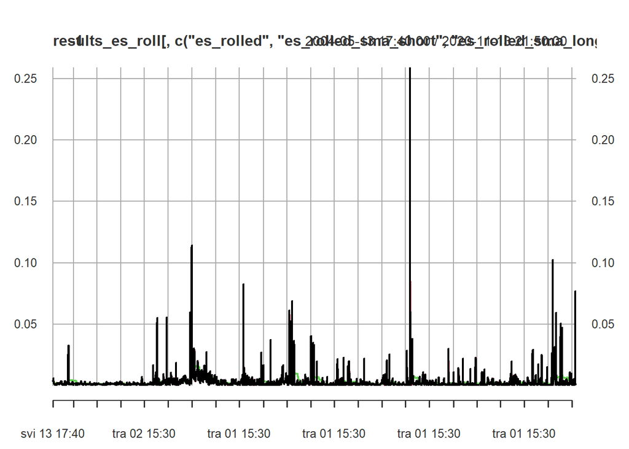

```r
results_es_roll$es_rolled <- na.locf(results_es_roll$es_rolled)
results_es_roll$es_rolled_sma_short <- TTR::SMA(results_es_roll$es_rolled, 50)
results_es_roll$es_rolled_sma_long <- TTR::SMA(results_es_roll$es_rolled, 5000)
results_es_roll <- na.omit(results_es_roll)
plot(results_es_roll[, c('es_rolled', 'es_rolled_sma_short', 'es_rolled_sma_long')] * -1)
```

Prcojenjeni ES možemo koristiti na razne načine. Ja sam isprobao:

1. Prodaja dionice kada ES prijeđe određeni threshold.
2. Prodaja pod 1. + skraćeni SMA veći od dugod SMA.
3. Prodaja kada ES prijeđe određeni povijesni kvantil.

Slijede rezultati pojedinih backtestova.

1. Backtest theshold

```r
# backtest threshold
indicator <- as.vector(zoo::coredata(results_es_roll$es_rolled * -1))
side <- vector(mode = 'integer', length = length(indicator))
for (i in 1:length(indicator)) {
  if (i == 1 || is.na(indicator[i-1])) {
    side[i] <- NA
  } else if (indicator[i-1] > 0.007) {  # izabrao doar parametar nakon nekoliko pkusaja
    side[i] <- 0
  } else {
    side[i] <- 1
  }
}
table(side)
```

```
## side
##      0      1
##  25713 295548
```

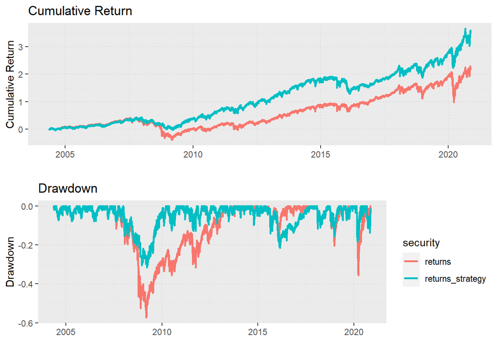

```r
results_es_roll$side <- side
results_es_roll$returns_strategy <- results_es_roll$returns * results_es_roll$side
charts.PerformanceSummary(results_es_roll[, c('returns', 'returns_strategy')], plot.engine = 'ggplot2')
```

2. Backtest SMA

```r
# backtest SMA
indicator <- as.vector(zoo::coredata(results_es_roll$es_rolled * -1))
indicator_short <- SMA(indicator, 100)
indicator_long <- SMA(indicator, 3000)
side <- vector(mode = 'integer', length = length(indicator))
for (i in 1:length(indicator)) {
  if (i == 1 || is.na(indicator_long[i-1])) {
    side[i] <- NA
  } else if (indicator_short[i-1] > 0.004 & indicator_short[i-1] > indicator_long[i-1]) {
    side[i] <- 0
  } else {
    side[i] <- 1
  }
}
table(side)
```

```
## side
##      0      1
##  44261 274001
```

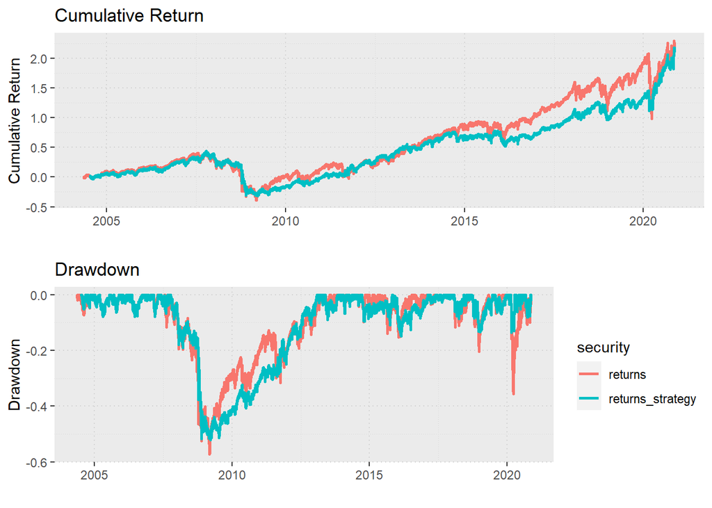

```r
results_es_roll$side <- side
results_es_roll$returns_strategy <- results_es_roll$returns * results_es_roll$side
charts.PerformanceSummary(results_es_roll[, c('returns', 'returns_strategy')], plot.engine = 'ggplot2')
```

3. Backtest kvantil

```r
# backtest SMA
indicator <- as.vector(zoo::coredata(results_es_roll$es_rolled * -1))
indicator_quantil <- roll::roll_quantile(indicator, 255*4, p = 0.95)
side <- vector(mode = 'integer', length = length(indicator))
for (i in 1:length(indicator)) {
  if (i == 1 || is.na(indicator_quantil[i-1])) {
    side[i] <- NA
  } else if (indicator[i-1] > indicator_quantil[i-1]) {
    side[i] <- 0
  } else {
    side[i] <- 1
  }
}
table(side)
```

```
## side
##      0      1
##  32868 287374
```

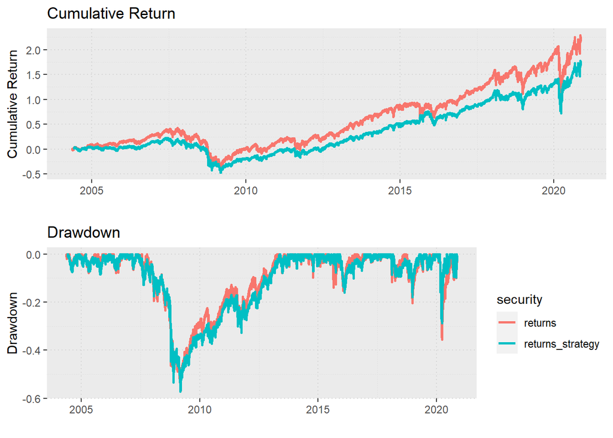

```r
results_es_roll$side <- side
results_es_roll$returns_strategy <- results_es_roll$returns * results_es_roll$side
charts.PerformanceSummary(results_es_roll[, c('returns', 'returns_strategy')], plot.engine = 'ggplot2')
```

### GENERALIZED AUTOREGRESSIVE SCORE ES (VAR) MODELS

Ova strategija se temelji na [sljedećem radu](https://journal.r-project.org/archive/2018/RJ-2018-064/RJ-2018-064.pdf). Citat od autora:

> TheGASpackage of Catania et al. (2016) provides a complete framework for modeling, estimatingand predicting time series processes for which the time variation in the parameters is driven by thescore of the conditional density function. … The economic relevance of this topic follows partly from the Basel Accords (currently the Basel IIIAccords), which impose that banks and financial institutions have to meet capital requirements, andmust rely on state-of-the-art risk systems. In particular, they must assess the uncertainty about thefuture values of their portfolios and estimate the extent and the likelihood of potential losses usinga risk measure. Nowadays, VaR and ES risk measures are the standards

Ukratko koristeći GAS pristup, predviđaju se VaR i ES mjere rizika za jedan dan unaprijed. Zatim se donose odluke o kupnji ili prodaji.

```r
# PARAMETRI
contracts = c('SPY')
distributions <- c('sstd')
scale_type <- c("Identity")  # , "Inv", "InvSqrt"
insample_length <- c(800, 1200)
refit_every <- 20


# import data
market_data_gas <- BatchGetSymbols(tickers = contracts, first.date = '1991-01-01')[[2]]
```

```
##
## Running BatchGetSymbols for:
##    tickers =SPY
## ^GSPC | yahoo (1|1) | Found cache file
## SPY | yahoo (1|1) | Found cache file - Got 93% of valid prices | Looking good!
```

```r
market_data_gas$returns <- market_data_gas$ret.adjusted.prices
market_data_gas <- na.omit(market_data_gas)

# specification of general autoregresive scoring model
estimate <- function(data, ticker = 'SPY', target = 'returns',
                     dist = 'sstd', scale_type = 'Identity',
                     insample_length = 1000) {

  # choose ticker
  data <- data[data$ticker == ticker, ]

  # gas apec
  GASSpec = UniGASSpec(
    Dist = dist,
    ScalingType = scale_type,
    GASPar = list(location = TRUE, scale = TRUE, skewness = TRUE, shape = TRUE))

  # Perform 1-step ahead rolling forecast with refit
  cluster <- makeCluster(25)
  Roll <- UniGASRoll(
    xts::xts(data[, target], order.by = data$ref.date),
    GASSpec,
    Nstart = insample_length,
    RefitEvery = refit_every,
    RefitWindow = c("moving"),
    cluster = cluster)
  stopCluster(cluster)
  rm("cluster")

  # forecasts_gas <- getForecast(Roll)
  alphas <- c(0.01, 0.05)
  var_gas <- quantile(Roll, probs = alphas)  # VaR
  colnames(var_gas) <- paste0('var_gas_', as.character(alphas * 100))
  es_gas <- GAS::ES(Roll, probs = alphas)
  colnames(es_gas) <- paste0('es_gas_', as.character(alphas * 100))

  # merge to market_data
  data <- cbind(data, rbind(matrix(NA, insample_length, length(alphas)), var_gas))
  data <- cbind(data, rbind(matrix(NA, insample_length, length(alphas)), es_gas))
  data
}

# estimate over all prameters
vectors <- expand.grid(contracts, distributions, scale_type, insample_length, stringsAsFactors = FALSE)
estimated <- purrr::pmap(
  .l = vectors,
  .f = ~ {estimate(market_data_gas, ticker = ..1, dist = ..2, scale_type = ..3, insample_length = ..4)}
)
names(estimated) <- apply(vectors, 1, paste, collapse = '_')
```

Slično kao i u prošloj strategiji, pravilo trgovanja će uključivati tri mjere:

1. Prodaja dionice kada ES prijeđe određeni threshold.
2. Prodaja pod 1. + skraćeni SMA veći od dugod SMA.
3. Prodaja kada ES prijeđe određeni povijesni kvantil.

3. Prodaja kada ES prijeđe određeni povijesni kvantil

```r
# parameters for backtest
quantile_widths <- 255 * 1:8
q <- c(0.001, seq(0.01, 0.05, 0.01))

# backtest
gas_backtest <- function(data, quantile_width = 255*4, quantile_p = 0.05) {

  # trading rule
  data <- na.omit(data)
  indicator <- as.vector(zoo::coredata(data$es_gas_1))

  # execute
  indicator_quantile <- roll::roll_quantile(indicator,
                                            width = quantile_width,
                                            p = quantile_p,
                                            min_obs = 10)
  # indicator_2 <- as.vector(zoo::coredata(backtest_data$forecasts_gas_skewness))
  side <- vector(mode = 'integer', length = length(indicator))
  for (i in 1:length(indicator)) {
    if (i == 1 || is.na(indicator_quantile[i-1])) {
      side[i] <- NA
    } else if (indicator[i-1] < indicator_quantile[i-1]) {
      side[i] <- 0
    } else {
      side[i] <- 1
    }
  }
  table(side, useNA = 'ifany')
  returns_strategy <- xts::xts(data$returns * side, order.by = zoo::index(data))
  perf <- na.omit(merge(data[, c('returns')], returns_strategy = returns_strategy))
  # p <- charts.PerformanceSummary(perf, plot.engine = 'ggplot2')
  return(perf)
}

# backtest
gas_estimated_xts <- lapply(estimated, function(x) xts::xts(x[, -c(7, 8)], order.by = x$ref.date))
argumenta_backtest <- expand.grid(names(gas_estimated_xts), quantile_widths, q, stringsAsFactors = FALSE)
backtested <- purrr::pmap(
  .l = argumenta_backtest,
  .f = ~ {gas_backtest(gas_estimated_xts[[..1]], quantile_width = as.numeric(..2), quantile_p = as.numeric(..3))}
)
names(backtested) <- gsub('\\.', '', apply(argumenta_backtest, 1, paste, collapse = '_'))

# save cumulative returns
cum_returns <- do.call(cbind, backtested)
cum_returns <- cum_returns[, c(1, seq(2, ncol(cum_returns), 2))]
colnames(cum_returns) <- c('returns', names(backtested))
cum_returns <- t(PerformanceAnalytics::Return.cumulative(cum_returns))
vars <- data.frame(data.table::tstrsplit(rownames(cum_returns), split = '_'))
colnames(vars) <- c('ticker', 'dist', 'type', 'window', 'quantile_win', 'p')
cum_returns <- cbind(cum_returns, vars)
cum_returns %>%
  filter(ticker == 'SPY') %>%
  arrange(desc(`Cumulative Return`))
```

|  | Cumulative Return | ticker | dist | type | window | quantile_win | p |
| --- | --- | --- | --- | --- | --- | --- | --- |
| SPY_sstd_Identity_ 800_ 765_0010 | 13.463218 | SPY | sstd | Identity | 800 | 765 | 0010 |
| SPY_sstd_Identity_ 800_2040_0050 | 12.917658 | SPY | sstd | Identity | 800 | 2040 | 0050 |
| SPY_sstd_Identity_ 800_ 510_0010 | 12.902193 | SPY | sstd | Identity | 800 | 510 | 0010 |
| SPY_sstd_Identity_ 800_2040_0040 | 12.698083 | SPY | sstd | Identity | 800 | 2040 | 0040 |
| SPY_sstd_Identity_ 800_ 255_0030 | 12.695657 | SPY | sstd | Identity | 800 | 255 | 0030 |
| SPY_sstd_Identity_ 800_2040_0030 | 12.599521 | SPY | sstd | Identity | 800 | 2040 | 0030 |
| SPY_sstd_Identity_ 800_1785_0040 | 12.545258 | SPY | sstd | Identity | 800 | 1785 | 0040 |
| SPY_sstd_Identity_ 800_ 255_0020 | 12.539001 | SPY | sstd | Identity | 800 | 255 | 0020 |
| SPY_sstd_Identity_ 800_ 255_0010 | 12.028012 | SPY | sstd | Identity | 800 | 255 | 0010 |
| SPY_sstd_Identity_ 800_1785_0030 | 11.637828 | SPY | sstd | Identity | 800 | 1785 | 0030 |

[output cut: 86 more lines]

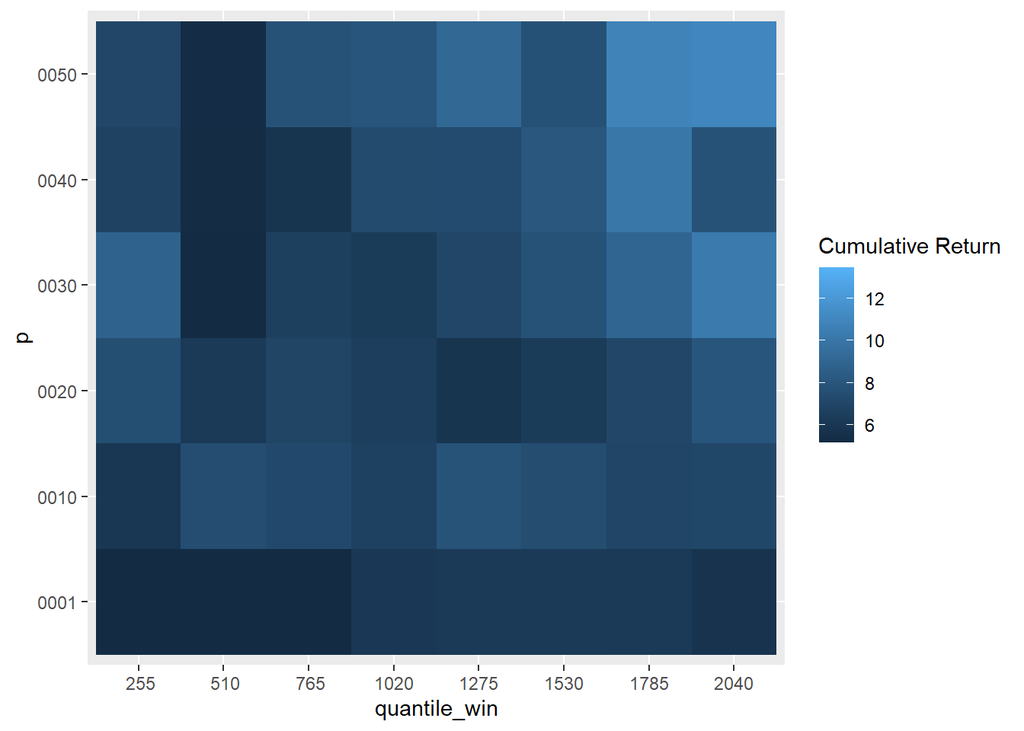

```r
# heatmap
ggplot(cum_returns[2:nrow(cum_returns), ], aes(quantile_win, p, fill= `Cumulative Return`)) +
  geom_tile()
```

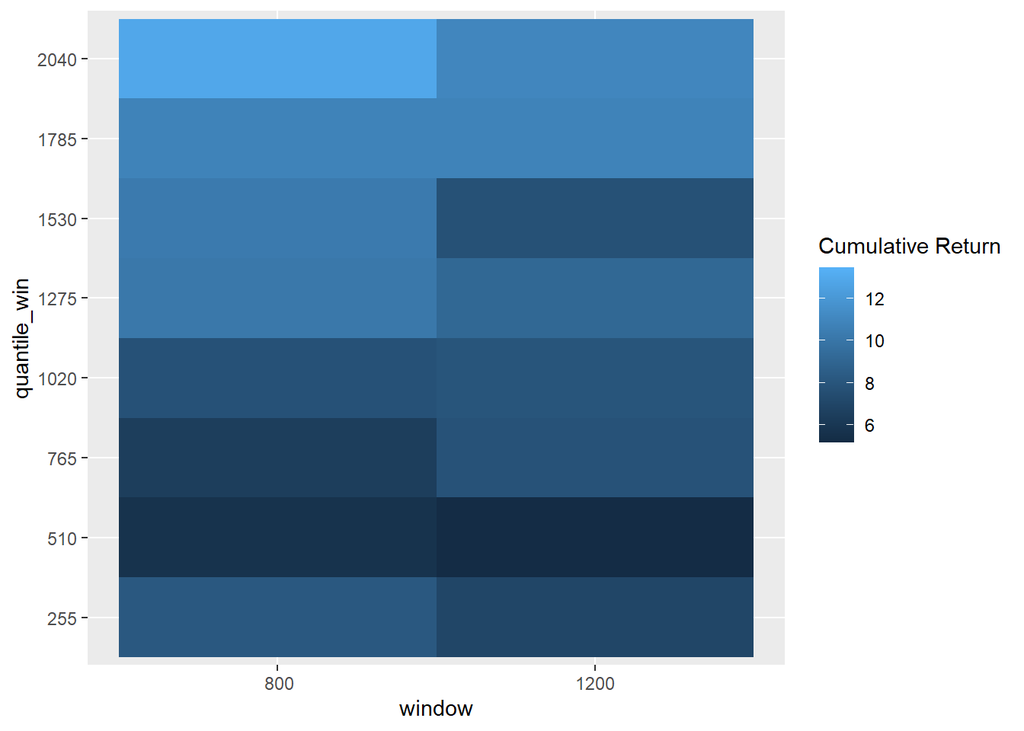

```r
ggplot(cum_returns[2:nrow(cum_returns), ], aes(window, quantile_win, fill= `Cumulative Return`)) +
  geom_tile()
```

### EVT STRATEGIJA

EVT je skraćenica za *extreme value theory*. Teorija nastoji objasniti ponašanje (distribuciju) ekstremnih vrijednosti određenog stohastičkog procesa. Davno je ustanovljeno da prinosi na dionice ne prate normalnu distribuciju. Repovi empirijske distribucije su deblji repova normalne distribucije, Drugim riječima, ekstremni događaji su u stvarnom svijetu znatno učestaliji (vjerojatniji) nego što bi bili u ‘normalnom’ svijetu.

Prema EVT, prinosi nakon određene razine prate generalnu Pareto distribuciju. Iako se po brzim testovima koje sam napravio čini da je ovo točno samo za prinose s dnevnom frekvencijom, koristio sam ovu teoriju za razvoj EVT strategije.

Strategija se sastoji od sljedećih koraka:

```r
# parameters
gpd_window_size <- 5000
threshold <- 0.0015

# roll gpd
gpd_roll <- frollapply_parallel(
  y = market_data$returns * -1,
  n_cores = -1,
  roll_window = gpd_window_size,
  FUN = function(x) {
    es <- evir::gpd(x, threshold = threshold, method = 'ml', information = 'expected')
    es <- evir::riskmeasures(es, c(0.999))[, 3]
  }
)
```

```
## [1] "Number of subsamples (max used cores): 65"
## [1] "The fucntion took -48.753054857254"
```

```r
gpd_roll <- lapply(gpd_roll, function(x) x[!is.na(x)])
gpd_roll <- unlist(purrr::flatten(gpd_roll))
gpd_roll <- c(rep(NA, gpd_window_size-1), gpd_roll)
gpd_roll <- cbind(market_data, es = gpd_roll)
gpd_roll <- na.omit(gpd_roll)
```

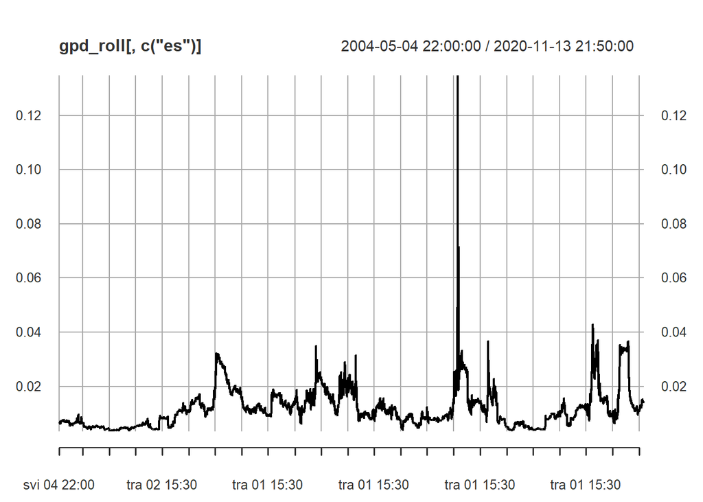

```r
# grafovi
plot(gpd_roll[, c('es')])
```

Backtest threshold

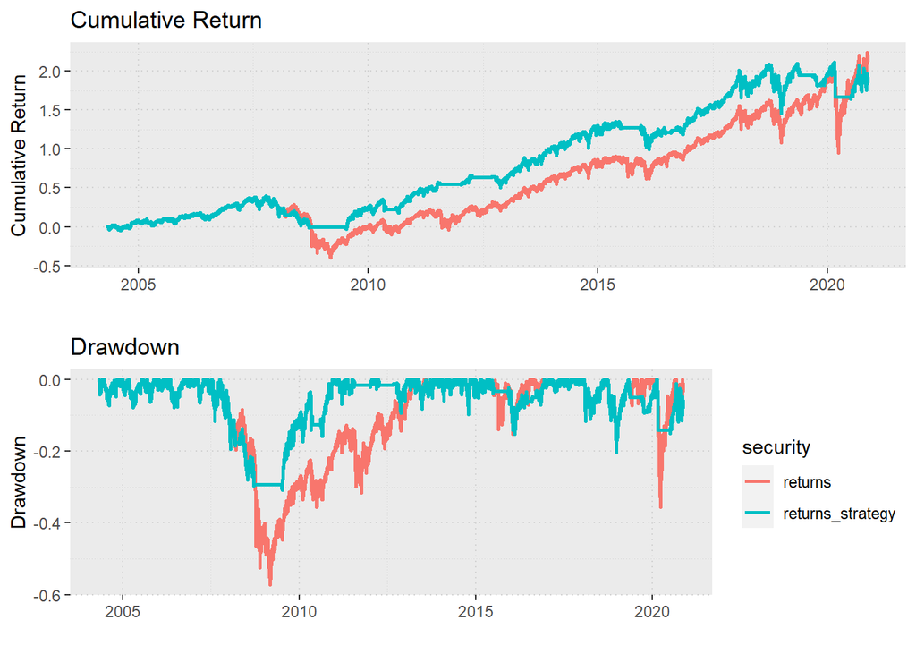

```r
# backtet functoin
backtest <- function(data, sma_long, sma_short) {

  # trading rule
  indicator <- as.vector(zoo::coredata(data$es))
  # indicator_q <- roll::roll_quantile(indicator, 12*8*255*5, p = 0.90, min_obs = 12*8*255)
  # indicator_sma_long <- as.vector(zoo::coredata(TTR::SMA(indicator, sma_long)))
  # indicator_sma_short <- as.vector(zoo::coredata(TTR::SMA(indicator, sma_short)))
  side <- vector(mode = 'integer', length = length(indicator))
  for (i in 1:length(indicator)) {
    if (i == 1 || is.na(indicator[i-1])) {
      side[i] <- NA
    } else if (indicator[i-1] > 0.015) {
      side[i] <- 0
    } else {
      side[i] <- 1
    }
  }

  # merge
  returns_strategy <- xts::xts(data$returns * side, order.by = zoo::index(data))
  perf <- na.omit(merge(data[, 'returns'], returns_strategy = returns_strategy))
  colnames(perf)[ncol(perf)] <- 'returns_strategy'
  return(perf)
}
backtest_results <- backtest(gpd_roll, 400, 50)
charts.PerformanceSummary(backtest_results, plot.engine = "ggplot2")
```

Backtest SMA cross

```r
# backtet functoin
backtest <- function(data, sma_long, sma_short) {

  # trading rule
  indicator <- as.vector(zoo::coredata(data$es))
  # indicator_q <- roll::roll_quantile(indicator, 12*8*255*5, p = 0.90, min_obs = 12*8*255)
  indicator_sma_long <- as.vector(zoo::coredata(TTR::SMA(indicator, sma_long)))
  indicator_sma_short <- as.vector(zoo::coredata(TTR::SMA(indicator, sma_short)))
  side <- vector(mode = 'integer', length = length(indicator))
  for (i in 1:length(indicator)) {
    if (i == 1 || is.na(indicator_sma_long[i-1])) {
      side[i] <- NA
    } else if (indicator[i-1] > 0.015 & indicator[i-1] > indicator_sma_long[i-1]) {
      side[i] <- 0
    } else {
      side[i] <- 1
    }
  }
  print(table(side))

  # merge
  returns_strategy <- xts::xts(data$returns * side, order.by = zoo::index(data))
  perf <- na.omit(merge(data[, 'returns'], returns_strategy = returns_strategy))
  colnames(perf)[ncol(perf)] <- 'returns_strategy'
  return(perf)
}
backtest_results <- backtest(gpd_roll, 5000, 20)
```

```
## side
##      0      1
##  46074 270687
```

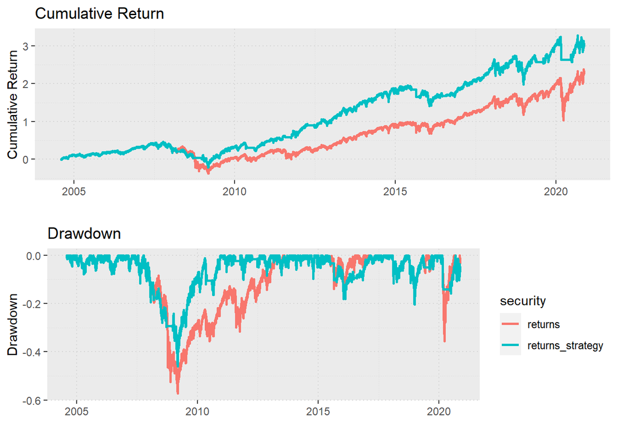

```r
charts.PerformanceSummary(backtest_results, plot.engine = "ggplot2")
```

### SPY VAR STRUCTURE

Ideju za ovu strategiju dobio sam za vrijeme proučavanja EVT. Umjesto da poučavam SPY kao jednu dionicu analizirat ću sve dionice koje su sastavnice SPY-a. Strategija se sastoji od sljedećih koraka:

1. Univerzum dionica čine sve sastavnice SP500. QC nema točan skup sastavnica, ali imaju skup QC500 koji vjerno odražava sastavnice SP500.
2. Za svaku dionicu u univerzumu se izračunava 0.999 i 0.001 kvantil na temelju prethodne 4 godine.
3. Za svaku dionicu se svaki sat provjerava je li ostvarila prinos manji od 0.001 percentila (vrlo veliki gubitak), vice versa.
4. Zbrajaju se svi prinosi koji zadovoljavaju točku 3.
5. Izračunava se EWM na temelju 30 posljednih vrijednosti iz 4. čime se dobiva glavni indikator za trgovanje. 6 Ako je vrijendost indikatora pod 5. veća od 0.5 prodajemo poziciju. Ponovno ulazimo u poziciju kada padne 0.5.

Kod i rezultati su dostupni u QC projektu SP500 Var structure.

### NOVI ALATI

1. Quantconnect je uveo opciju optimizacije parametara. Izabire se jedan ili više parametara koji se žele optimizirati i veličina koja se optimizira (npr. Sharp ratio). Usluga se plaća po satu (cca 3$ po satu). Na kraju se pokazuju rezultati svih strategija s slikama i tablicama.
2. SimFin+ omogućuje korištenje fundamentalnih podataka za samo 20$ mjesečno. dobar omjer cijene i kvalitete.

### IDEJE ZA DALJE

1. Uspostavit *data vendore* za Lean lokalno.
2. Iskorisit dnevne poatke o drugim dionicama, istrenirat model na razdoblju 2000-2015 i testirat modele na razdoblju 2016-2020 na svim dionicama.